# My Bechdel test

Rick SCHNEIDER

1 octobre 2018

https://data.world/sharon/bechdel-test -> new data for bechdel test!!!!!!!

# Packages:

```r
library(tidyverse)
library(ggplot2)
library(readr)
library(stringr)
```

# Introduction

The goal of this new bechdel test is to measure the gender imbalance in movies.

The original Bechdel test tests for 3 criterias: 1)Are there at least 2 women in the movie? 2)Do they have a conversation together? 3)Is that conversation about somthing else than a man?

Fivethirtyeight has created a new Bechdel test.

Import data from the new Benchdel test:

```r
#new_bechdel <- read_csv("https://raw.githubusercontent.com/fivethirtyeight/data/master/next-bechdel/nextBechdel_allTests.csv")

cast_gender <- read_csv("https://raw.githubusercontent.com/fivethirtyeight/data/master/next-bechdel/nextBechdel_castGender.csv")
crew_gender <- read_csv("https://raw.githubusercontent.com/fivethirtyeight/data/master/next-bechdel/nextBechdel_crewGender.csv")
```

# Analyis of cast_gender & crew_gender

Lets start by having a look the 2 data sets that we have to create our benchdel test:

cast_gender:

```r
#View(new_bechdel)

head(cast_gender)
```

```
## # A tibble: 6 x 6
##   MOVIE                  ACTOR      CHARACTER_NAME  TYPE    BILLING GENDER
##   <chr>                  <chr>      <chr>           <chr>     <int> <chr>
## 1 Tyler Perrys Boo! A ~ Tyler Per~ Madea/Joe/Brian Leading       1 Male
## 2 Tyler Perrys Boo! A ~ Cassi Dav~ Aunt Bam        Suppor~       2 Female
## 3 Tyler Perrys Boo! A ~ Patrice L~ Hattie          Suppor~       3 Female
## 4 Tyler Perrys Boo! A ~ Yousef Er~ Jonathan        Suppor~       4 Male
## 5 Tyler Perrys Boo! A ~ Lexy Pant~ Leah            Suppor~       5 Female
## 6 Tyler Perrys Boo! A ~ Andre Hall Quinton         Suppor~       6 Male
```

```r
dim(cast_gender)
```

```
## [1] 2075    6
```

```r
names(cast_gender)
```

```
## [1] "MOVIE"          "ACTOR"          "CHARACTER_NAME" "TYPE"
## [5] "BILLING"        "GENDER"
```

```r
summary(cast_gender)
```

```
##     MOVIE              ACTOR           CHARACTER_NAME
##  Length:2075        Length:2075        Length:2075
##  Class :character   Class :character   Class :character
##  Mode  :character   Mode  :character   Mode  :character
##
##
##
##
##      TYPE              BILLING          GENDER
##  Length:2075        Min.   :  1.00   Length:2075
##  Class :character   1st Qu.: 11.00   Class :character
##  Mode  :character   Median : 23.00   Mode  :character
##                     Mean   : 28.21
##                     3rd Qu.: 39.00
##                     Max.   :122.00
##                     NA's   :1
```

```r
#View(cast_gender)

#How many different movies are in the df?
cast_gender %>%
  distinct(MOVIE) %>%
  summarise(count_movies_cast=n())
```

```
## # A tibble: 1 x 1
##   count_movies_cast
##               <int>
## 1                50
```

cast_gender is a 2075x6 data frame with the variables “MOVIE” (name of the movie), “ACTOR” (name of the casted actor), “CHARACTER_NAME” (name of the character in the movie), “TYPE” (which role did the character play? Was it a leading, supporting,… one?), “BILLING” (billing numer) and “GENDER” (female or male). The data frame contains information about 50 different movies.

Lets have a look at crew_gender:

```r
head(crew_gender)
```

```
## # A tibble: 6 x 7
##   MOVIE  DEPARTMENT  FULL_NAME FIRST_NAME IMDB    GENDER_PROB GENDER_GUESS
##   <chr>  <chr>       <chr>     <chr>      <chr>         <dbl> <chr>
## 1 Rogue~ Directed b~ Gareth E~ Gareth     http:/~        0.97 male
## 2 Rogue~ Writing Cr~ Chris We~ Chris      http:/~        0.93 male
## 3 Rogue~ Writing Cr~ Tony Gil~ Tony       http:/~        1    male
## 4 Rogue~ Writing Cr~ John Kno~ John       http:/~        0.99 male
## 5 Rogue~ Writing Cr~ Gary Whi~ Gary       http:/~        1    male
## 6 Rogue~ Writing Cr~ George L~ George     http:/~        0.99 male
```

```r
dim(crew_gender)
```

```
## [1] 10029     7
```

```r
names(crew_gender)
```

```
## [1] "MOVIE"        "DEPARTMENT"   "FULL_NAME"    "FIRST_NAME"
## [5] "IMDB"         "GENDER_PROB"  "GENDER_GUESS"
```

```r
summary(crew_gender)
```

```
##     MOVIE            DEPARTMENT         FULL_NAME
##  Length:10029       Length:10029       Length:10029
##  Class :character   Class :character   Class :character
##  Mode  :character   Mode  :character   Mode  :character
##
##
##
##
##   FIRST_NAME            IMDB            GENDER_PROB     GENDER_GUESS
##  Length:10029       Length:10029       Min.   :0.0000   Length:10029
##  Class :character   Class :character   1st Qu.:0.7500   Class :character
##  Mode  :character   Mode  :character   Median :0.9900   Mode  :character
##                                        Mean   :0.7597
##                                        3rd Qu.:1.0000
##                                        Max.   :1.0000
##                                        NA's   :501
```

```r
#View(crew_gender)

#How many different movies are in the df?
crew_gender %>%
  distinct(MOVIE) %>%
  summarise(count_movies_crew=n())
```

```
## # A tibble: 1 x 1
##   count_movies_crew
##               <int>
## 1                19
```

crew_gender is a 10029x7 data frame with the variables “MOVIE”, “DEPARTMENT” (in which department did the crew member work?), “FULL_NAME”, “FIRST_NAME”, “IMDB” (link to the IMDb page of the person in question), “GENDER_PROB” (the probability of the name being female (->0) or male (->1)) and “GENDER_GUESS” (the guess of the gender based on the probability). crew_gender contais information about 19 different movies. All movie names have the supplement of “(2016)” in their name which can be removed.

# My first Benchdel criteria:

The goal of my personal benchdel test is to test for gender inqueality. Therefore, I am going to introduce a few gender criterias that a movie should fulfill to pass my test. The first criterias that I would like t take into consideration are the following: 1) Over 30% of the cast should be female 2) Leading roles should be 40% female

Next the data set is analysed to see if those criteria are reasonable. In a next step, if necessary, we are going to adapt the criteria

# Analysis of the first Benchdel criteria:

Lets have a look at the feasability of our first criterium, which is: “Over 30% of the cast should be female”:

```r
#create  count table:
count_gender <- table(cast_gender$GENDER)
count_gender
```

```
##
##  Female    Male Unknown
##     580    1247     248
```

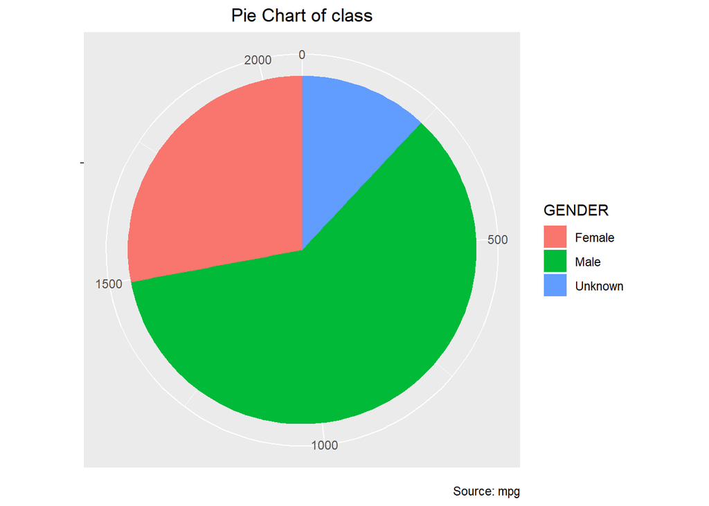

```r
#create a pie chart to visualize the count:
pie <- ggplot(cast_gender, aes(x = "", fill = factor(GENDER))) +
  geom_bar(width = 1) +
  theme(axis.line = element_blank(),
        plot.title = element_text(hjust=0.5)) +
  labs(fill="GENDER",
       x=NULL,
       y=NULL,
       title="Pie Chart of class",
       caption="Source: mpg")

pie + coord_polar(theta = "y", start=0)
```

```r
#calculate the percentage ratio:
count_gender <- data.frame(count_gender)
perc_female <- count_gender[count_gender$Var1=="Female",2]/(count_gender[count_gender$Var1=="Female",2]+count_gender[count_gender$Var1=="Male",2])
perc_female*100
```

```
## [1] 31.74603
```

On average over all movies in our database, around 31.74% of the cast is female. As such, our requirement to have at least 30% females in a cast seems to be a feasible requirement without excluding all the movies.

Lets have a look at the feasability of our first criterium, which is: “Leading roles should be 40% female”:

```r
#filter out leading characters:
leading_cast <- cast_gender %>%
                  filter(TYPE == "Leading")
#geberate a frequency count table:
leading_gender_count = table(leading_cast$GENDER)
leading_gender_count
```

```
##
##  Female    Male Unknown
##      24      40       2
```

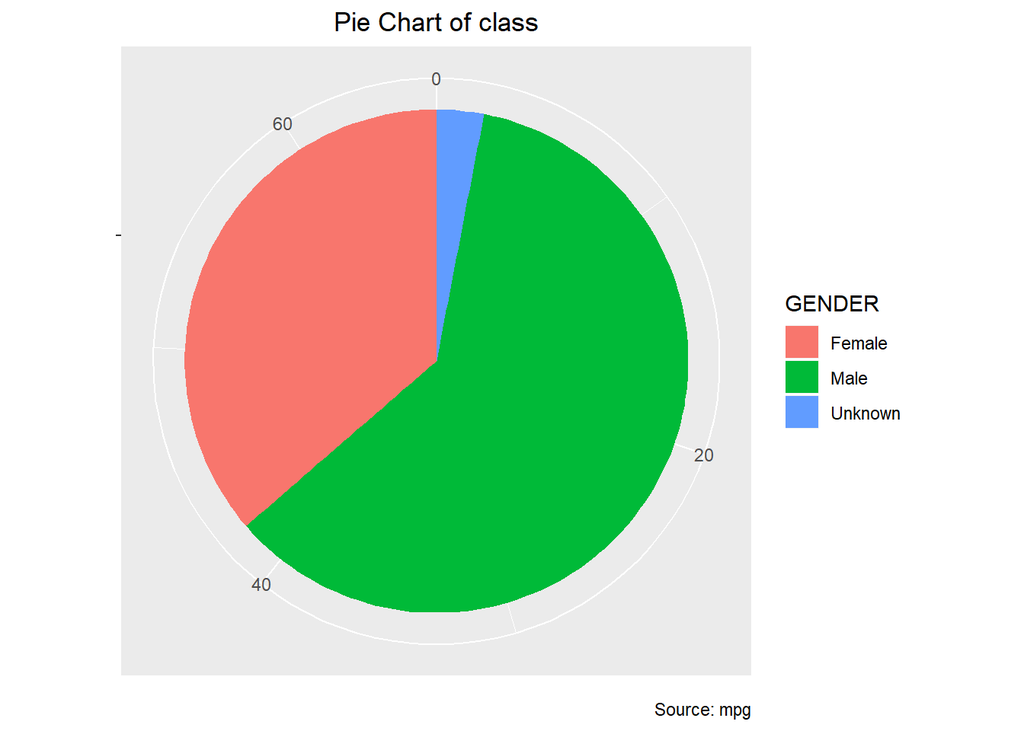

```r
#generate a pie chart with the gender of leading people:
pie <- ggplot(leading_cast, aes(x = "", fill = factor(GENDER))) +
  geom_bar(width = 1) +
  theme(axis.line = element_blank(),
        plot.title = element_text(hjust=0.5)) +
  labs(fill="GENDER",
       x=NULL,
       y=NULL,
       title="Pie Chart of class",
       caption="Source: mpg")

pie + coord_polar(theta = "y", start=0)
```

```r
#calculate the percentage ratio:
leading_gender_count <- data.frame(leading_gender_count)
perc_female <- leading_gender_count[leading_gender_count$Var1=="Female",2]/(leading_gender_count[leading_gender_count$Var1=="Female",2]+leading_gender_count[leading_gender_count$Var1=="Male",2])
perc_female*100
```

```
## [1] 37.5
```

# My first Benchdel test:

Criterium 1:

```r
#As we need to count the gender for a few criteria, we create a function to have a reproductible code. In R, functions cannot return multiple values, so we need to create 2 seperate functions:
#count females function:
f_count_fem <- function(df){
  num_fem <- df %>%
                  filter(GENDER == "Female") %>%
                  group_by(MOVIE) %>%
                  summarise(count_fem_cast = n())
  return(num_fem)}

#count males function:
f_count_male <- function(df){
  num_male <- df %>%
                  filter(GENDER == "Male") %>%
                  group_by(MOVIE) %>%
                  summarise(count_male_cast = n())
  return(num_male)}

num_fem <- f_count_fem(cast_gender)
num_male <- f_count_male(cast_gender)

#Join the count per movie data frames and calculate the ratio:
my_bechdel <- inner_join(num_fem,num_male,by="MOVIE")
my_bechdel <- my_bechdel %>%
                mutate(crit1_test = count_fem_cast/(count_fem_cast+count_male_cast),
                       crit1 = case_when(
                          crit1_test > 0.3  ~ 1, crit1_test <= 0.3 ~ 0))
table(my_bechdel$crit1)
```

```
##
##  0  1
## 19 31
```

```r
#View(my_bechdel)
```

We see that 31 out of the 50 movies pass this criterium

criterium 2:

```r
#use functions to count males and females having a leading role:
num_fem <- f_count_fem(leading_cast)
num_male <- f_count_male(leading_cast)
#View(num_fem)

#Reminder: leading_cast -> information about the leading actors for every movie
#select a list of distinct movies where we have information about a leading actor
my_bechdel2 <- leading_cast %>%
                  select(MOVIE) %>%
                   distinct(MOVIE)

#add the female count column:
my_bechdel2 <- right_join(num_fem,my_bechdel2,by="MOVIE")
my_bechdel2[is.na(my_bechdel2[,2]),2]=0
#add a male count column:
my_bechdel2 <- right_join(num_male,my_bechdel2,by="MOVIE")
my_bechdel2[is.na(my_bechdel2[,2]),2]=0

#calculate the ratio:
my_bechdel2 <-  my_bechdel2 %>%
                    mutate(crit2_test = count_fem_cast/(count_male_cast+count_fem_cast))
#final crit2 (1: passed criterium, 0: not passed)
my_bechdel2 <-  my_bechdel2 %>%
                    mutate(crit1_test = count_fem_cast/(count_fem_cast+count_male_cast),
                       crit2 = case_when(
                          crit2_test > 0.4  ~ 1, crit2_test <= 0.4 ~ 0))
table(my_bechdel2$crit2)
```

```
##
##  0  1
## 15 16
```

```r
#16 out of 31 movies pass this part of the test (+/- 50%)

#View(my_bechdel2)
```

Putting the criteria together:

```r
rick_test <- my_bechdel
rick_test <- rick_test %>%
                left_join(my_bechdel2,by="MOVIE") %>%
                select(MOVIE,crit1,crit2)

#if there is no data available, put a -1
rick_test[is.na(rick_test$crit2),"crit2"]=-1

#how many crit2 are equal to -1?
rick_test %>%
  filter(crit2 == -1) %>%
  summarise(count_minus1 = n())
```

```
## # A tibble: 1 x 1
##   count_minus1
##          <int>
## 1           19
```

```r
#View(rick_test)
```

# First evaluation:

We are going to look at the different roles of the of the cast and we are going to check how much data is actually available for the different categories.

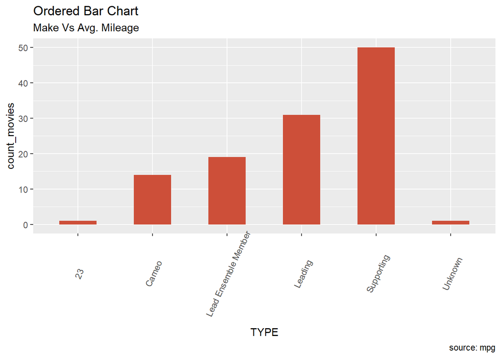

```r
#this variable stores the amount of data we have in the type column with respect to different movies
types_count <- cast_gender %>%
                  select(MOVIE,TYPE) %>%
                  group_by(TYPE) %>%
                  distinct(MOVIE) %>%
                  summarize(count_movies=n())

#barplot of our resulting count table:
ggplot(types_count, aes(x=TYPE, y=count_movies)) +
  geom_bar(stat="identity", width=.5, fill="tomato3") +
  labs(title="Ordered Bar Chart",
       subtitle="Make Vs Avg. Mileage",
       caption="source: mpg") +
  theme(axis.text.x = element_text(angle=65, vjust=0.6))
```

We can see that the type “leading” provides data on actors with main roles for 31 movies. Only the type “supporting” provides data on every movie. As a result, we should create a criteria based on the proportion of female people with supporting roles in the movies.

We are going to extend the test as follows: 1) Over 30% of the cast should be female 2) Leading roles should be 40% female 3) The supporting actors should be 50% female

We are going to decide in a later step if we are going to reject criterium 2), or if we are going to find a more flexible soluion for this problem.

Lets have a look at the feasability of our third criterium, which is: “The supporting actors should be 50% female”:

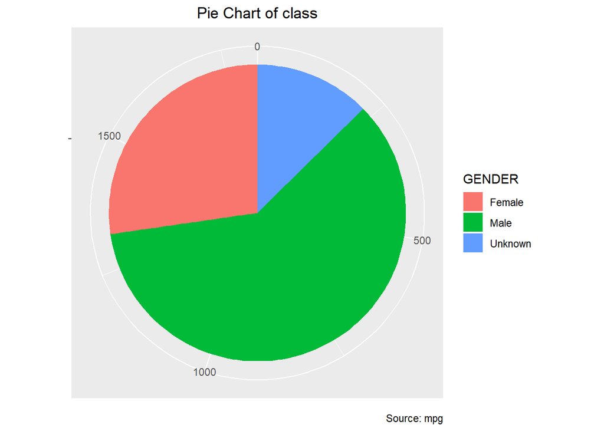

```r
supp_gender <- cast_gender %>%
                  filter(TYPE == "Supporting")

#create a pie chart to visualize the count:
pie <- ggplot(supp_gender, aes(x = "", fill = factor(GENDER))) +
  geom_bar(width = 1) +
  theme(axis.line = element_blank(),
        plot.title = element_text(hjust=0.5)) +
  labs(fill="GENDER",
       x=NULL,
       y=NULL,
       title="Pie Chart of class",
       caption="Source: mpg")

pie + coord_polar(theta = "y", start=0)
```

Criterium 3:

```r
#use functions to count males and females having a supporting role:
num_fem <- f_count_fem(supp_gender)
num_male <- f_count_male(supp_gender)
#View(num_fem)

#select a list of distinct movies where we have information about a supporting actor
my_bechdel3 <- supp_gender %>%
                  select(MOVIE) %>%
                   distinct(MOVIE)
#View(my_bechdel3)
#add the female count column:
my_bechdel3 <- right_join(num_fem,my_bechdel3,by="MOVIE")
my_bechdel3[is.na(my_bechdel3[,2]),2]=0
#add a male count column:
my_bechdel3 <- right_join(num_male,my_bechdel3,by="MOVIE")
my_bechdel3[is.na(my_bechdel3[,2]),2]=0

#calculate the ratio:
my_bechdel3 <-  my_bechdel3 %>%
                    mutate(crit3_test = count_fem_cast/(count_male_cast+count_fem_cast))
#final crit3 (1: passed criterium, 0: not passed, -1 if NA as we do not have enough data)
my_bechdel3 <-  my_bechdel3 %>%
                    mutate(crit1_test = count_fem_cast/(count_fem_cast+count_male_cast),
                       crit3 = case_when(
                          crit3_test > 0.4  ~ 1,
                          crit3_test <= 0.4 ~ 0,
                          is.na(crit3_test) == TRUE ~ -1))
table(my_bechdel3$crit3)
```

```
##
##  0  1
## 37 13
```

Putting the criteria together:

```r
#join to generate new df with 3 criteria:
rick_test <- rick_test %>%
                left_join(my_bechdel3,by="MOVIE") %>%
                select(MOVIE,crit1,crit2,crit3)

#rick_test <- rick_test %>%
#                mutate(result = crit1+crit2+crit3) %>%
#                filter(result == 2)
#View(rick_test)
```

# COnsideration of further criteria and solution for incomplete data

As already pointed above, the dataframe crew_gender contains only information on 19 different movies. In addition, our 3 criteria already exclude a few movies due to insufficient data.

We need a solution for this. There are 3 possible scenarios:

a)We do our final test only on the movies where we have all information for our chosen tests b)we change our criteria in order to test for all the movies c)we come up with a formula that allows to take missing data into account for the total test

While a) is a convenient solution, it strongly limits our test, that can only be applied on a few movies. In b), we are missing out on highly informative criteria. A solution for c) could look as follows: A movie is eligible for the test if there is enough data on 4 out of the 5 criteria (for example),if 5 –> pass 3 tests and be very close to pass the 4th (we need to introduce a closeness measure!); if 4 –> pass 3 tests )

Criterium 4:

```r
#generate a dataframe with the top 5 payed actors for every movie:
top_pay <- cast_gender %>%
              filter(BILLING %in% c(1,2,3,4,5))

#number of females in the top 5 for every movie:
num_fem <- f_count_fem(top_pay)

#initialize with a list of all the movies:
my_bechdel4 <- cast_gender %>%
                  select(MOVIE) %>%
                  distinct()

#add the female count column:
my_bechdel4 <- right_join(num_fem,my_bechdel4,by="MOVIE")
my_bechdel4[is.na(my_bechdel4[,2]),2]=0

my_bechdel4 <-  my_bechdel4 %>%
                    mutate(
                       crit4 = case_when(
                          count_fem_cast > 0  ~ 1,
                          count_fem_cast == 0  ~ 0,
                          ))

table(my_bechdel4$crit4)
```

```
##
##  0  1
##  3 47
```

This test is clearly not restricting enough as 47 out of 50 movies pass it. To find a good alternative, we are going to plot the relation of women to men for the top 5, top 4 and top 3 highest paid actors for every movie

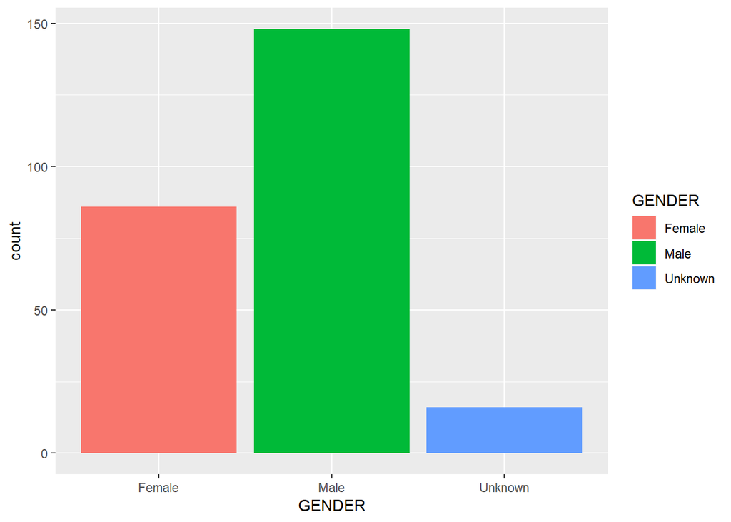

```r
#store top 5 , top 4 and top 3 payed actors respectively:
top_pay5 <- top_pay
top_pay4 <- cast_gender %>%
              filter(BILLING %in% c(1,2,3,4))
top_pay3 <- cast_gender %>%
              filter(BILLING %in% c(1,2,3))



g5 <- ggplot(top_pay5,aes(GENDER) ) + geom_bar(aes(fill = GENDER))
g4 <- ggplot(top_pay4,aes(GENDER) ) + geom_bar(aes(fill = GENDER))
g3 <- ggplot(top_pay3,aes(GENDER) ) + geom_bar(aes(fill = GENDER))

g5
```

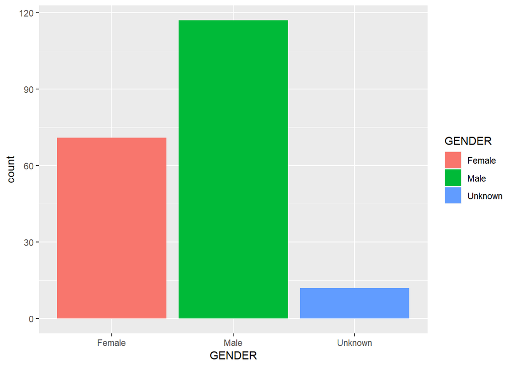

```r
g4
```

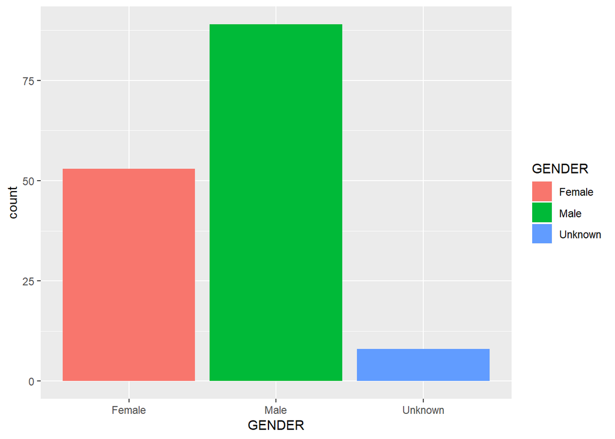

```r
g3
```

Finally, we can introduce a very strong criterium, that allows a movie to pass the test immediatly. If the movie does not pass th criterium, it will no longer be taken into consideration for the evaluation of the others. Lets have a look at the crew_gender dataset, to be more precise, at the different departments:

```r
#store the different departments:
dep <- crew_gender %>%
          select(DEPARTMENT) %>%
          distinct()
dep
```

```
## # A tibble: 29 x 1
##    DEPARTMENT
##    <chr>
##  1 Directed by_
##  2 Writing Credits _
##  3 Produced by_
##  4 Music by_
##  5 Cinematography by_
##  6 Film Editing by_
##  7 Casting By_
##  8 Production Design by_
##  9 Art Direction by_
## 10 Set Decoration by_
## # ... with 19 more rows
```

Lets have a look at the feasability of our fifth criterium:

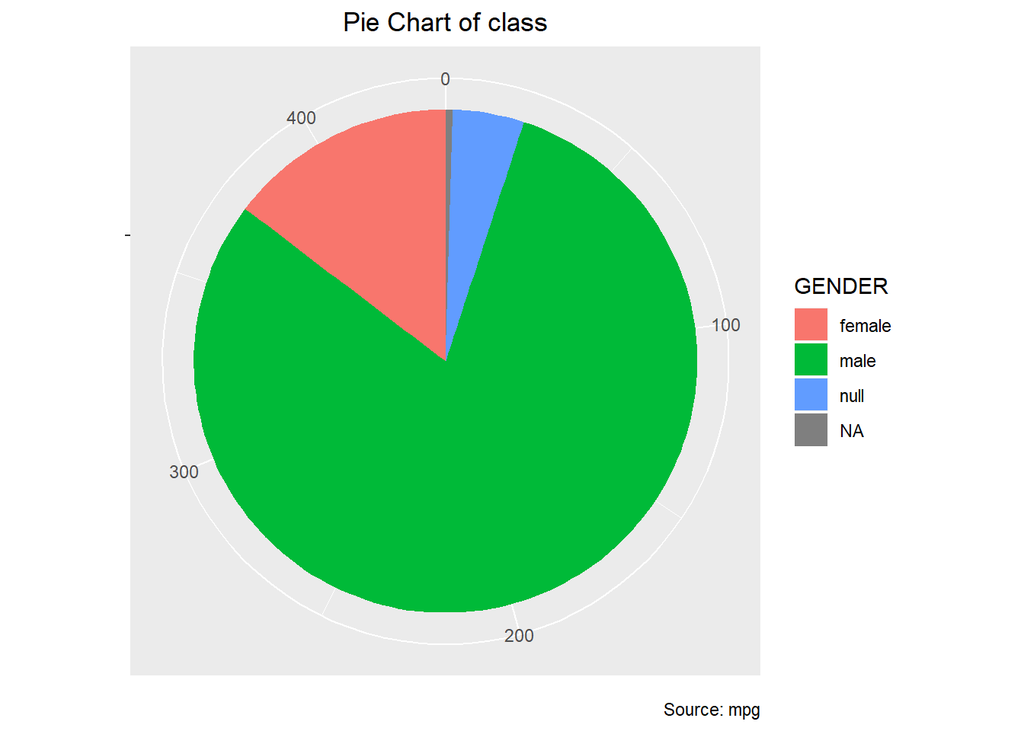

```r
#first, modify the crew_gender data set to make it suitable for our analysis.
#change the name from GENDER_GUESS to GENDER:
crew_gender <- crew_gender %>% rename(GENDER = GENDER_GUESS)
#delete the "-(2016)" that is added to every movie, so that we can perfom a join operator
crew_gender <- crew_gender %>% mutate(MOVIE = str_sub(MOVIE,1,str_length(MOVIE)-7))

#crew that does stunts
stunt <- crew_gender %>%
            filter(DEPARTMENT == "Stunts_")

#create a pie chart to visualize the count:
pie <- ggplot(stunt, aes(x = "", fill = factor(GENDER))) +
  geom_bar(width = 1) +
  theme(axis.line = element_blank(),
        plot.title = element_text(hjust=0.5)) +
  labs(fill="GENDER",
       x=NULL,
       y=NULL,
       title="Pie Chart of class",
       caption="Source: mpg")
pie + coord_polar(theta = "y", start=0)
```

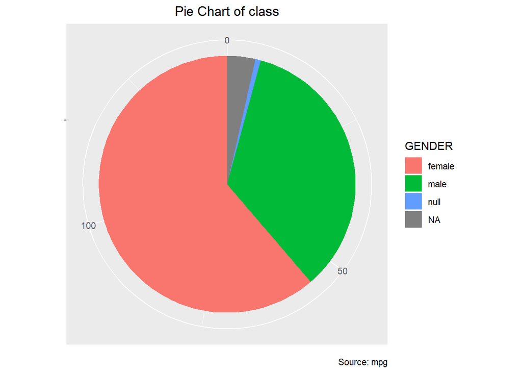

```r
#crew that does make-up:
makeup <- crew_gender %>%
            filter(DEPARTMENT == "Makeup Department_")

#create a pie chart to visualize the count:
pie2 <- ggplot(makeup, aes(x = "", fill = factor(GENDER))) +
  geom_bar(width = 1) +
  theme(axis.line = element_blank(),
        plot.title = element_text(hjust=0.5)) +
  labs(fill="GENDER",
       x=NULL,
       y=NULL,
       title="Pie Chart of class",
       caption="Source: mpg")
pie2 + coord_polar(theta = "y", start=0)
```

There is a higher proportion of male makeup artists than female stuntman.

criterium 5:

```r
#count females function:
f_count_fem_crew <- function(df){
  num_fem <- df %>%
                  filter(GENDER == "female") %>%
                  group_by(MOVIE) %>%
                  summarise(count_fem_cast = n())
  return(num_fem)}

#count males function:
f_count_male_crew <- function(df){
  num_male <- df %>%
                  filter(GENDER == "male") %>%
                  group_by(MOVIE) %>%
                  summarise(count_male_cast = n())
  return(num_male)}

#number of female stunman:
num_fem_stunt <- f_count_fem_crew(stunt)

#number of male makeup artists:
num_male_makeup <- f_count_male_crew(makeup)

#initialize as list of all movies:
my_bechdel5 <- cast_gender %>%
                  select(MOVIE) %>%
                  distinct()
View(my_bechdel5)

#add female stuntman count column:
my_bechdel5 <- right_join(num_fem_stunt,my_bechdel5,by="MOVIE")
#replace NAs by 0
my_bechdel5[is.na(my_bechdel5[,2]),2]=0

#add male makeup artists:
my_bechdel5 <- right_join(num_male_makeup,my_bechdel5,by="MOVIE")
#replace NAs by 0
my_bechdel5[is.na(my_bechdel5[,2]),2]=0

#create the crit5 column: if not 0 in both columns for 1 movie --> pass test
my_bechdel5 <-  my_bechdel5 %>%
                    mutate(
                       crit5 = case_when(
                          count_male_cast != 0 & count_fem_cast != 0 ~ 1, #if both are different from 0, pass test(->1)
                          count_male_cast == 0 | count_fem_cast == 0 ~ 0 #if one at least is equal to 0 , do not pass the test (->0)
                          ) )
table(my_bechdel5$crit5)
```

```
##
##  0  1
## 47  3
```

```r
#View(my_bechdel5)
```

# Additional data

This data set contains the revenues

```r
#revenue <- read_csv("data/Bechdel-master_revenue.csv")

#delete the index column and prepare table for join operation:
#revenue <- revenue %>%
#              select(-1) %>%
#              rename(MOVIE=Movie)
#View(revenue)

#join the data with a list of movies that we are going to test:
#movie_list <- cast_gender %>%
#                  select(MOVIE) %>%
#                  distinct()
#View(movie_list)
#revenue <- inner_join(movie_list,revenue,by="MOVIE")
#View(revenue)
```

Problems: many NAs, not very useful data. Very difficult to join the table based on the name of the movies…

# Ressources

http://bechdeltest.com/

http://poly-graph.co/bechdel/

https://pudding.cool/2017/03/film-dialogue/

https://fivethirtyeight.com/features/the-dollar-and-cents-case-against-hollywoods-exclusion-of-women/

https://fivethirtyeight.com/features/the-workplace-is-even-more-sexist-in-movies-than-in-reality/